# Ford GoBike Rides Insights

## by Chisom Eluwa

## Investigation Overview

> In this investigation, I was interested to see how different variables showed bike riders behavioral patterns on the system. I focus on all variable of interest to understand their distribution and their relationships with the frequencies of rides per hour, day. My goal is to discover how these variables influence trip durations, riding hours, and riding days of the week.

## Dataset Overview

> > The dataset contains data of 183,000 rides made in a bike-sharing system covering the San Francisco Bay area. Data features include duration (secs) and others such as DateTime, customer type, gender, as well as some additional variables. The dataset can be downloaded from [here] (https://console.cloud.google.com/marketplace/details/san-francisco-public-data/sf-bike-share?pli=1&project=graphite-argon-344013)

```python
# Hide codes

from IPython.display import HTML

HTML('''<script>
code_show=true;
function code_toggle() {
 if (code_show){
 $('div.input').hide();
 } else {
 $('div.input').show();
 }
 code_show = !code_show
}
$( document ).ready(code_toggle);
</script>
<form action="javascript:code_toggle()"><input type="submit" value="Click here to toggle on/off the raw code."></form>''')
```

## Distribution of Ages of Ford Bike Members

The ages of members in the dataset take a range of values. We see a distribution slighly skewed to the right with alot of observations within ages 19-45 for the members.

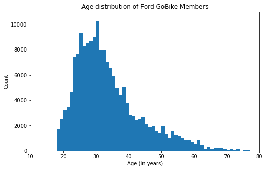

```python
# Plot a new viz of age distribution from Members Year of Birth Column

binsize = 1
bins = np.arange(0, ford_bikes['member_birth_year'].astype(float).max()+binsize, binsize)

plt.figure(figsize=[8, 5])
plt.hist(data = ford_bikes, x = 'member_birth_year', bins = bins);
plt.axis([1939, 2009, 0, 11000])
plt.xticks([1939, 1949, 1959, 1969, 1979, 1989, 1999, 2009], [(2019-1939), (2019-1949), (2019-1959), (2019-1969), (2019-1979), (2019-1989), (2019-1999), (2019-2009)])
plt.gca().invert_xaxis()
plt.xlabel('Age (in years)')
plt.ylabel('Count')
plt.title('Age distribution of Ford GoBike Members');
```

## Percentage of Users who share all their bike rides

We observe that some users share all their rides while others do not. There are only 10% of total users who share their rides.

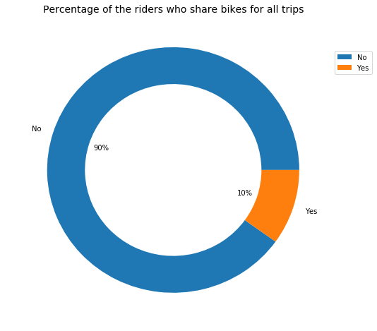

```python
sharing = ford_bikes.bike_share_for_all_trip.value_counts()
sharing.plot(kind='pie', figsize=(8,8), wedgeprops={'width':0.3}, autopct='%1.0f%%');
plt.title('Percentage of the riders who share bikes for all trips', size=14);
plt.legend(bbox_to_anchor=(1, 0.9), loc='upper left');
plt.axis("off");
```

## Distribution of Rides by Hours of the day

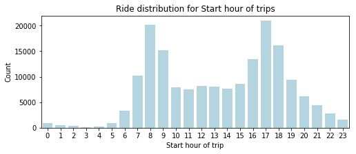

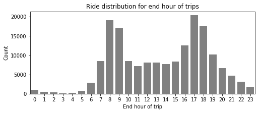

```python
plt.figure(figsize=(8,3))
sns.countplot(data=ford_bikes, x='start_hour', color='lightblue')
plt.ylabel('Count')
plt.xlabel('Start hour of trip')
plt.title('Ride distribution for Start hour of trips');


plt.figure(figsize=(8,3))
sns.countplot(data=ford_bikes, x='end_hour', color='grey')
plt.ylabel('Count')
plt.xlabel('End hour of trip')
plt.title('Ride distribution for end hour of trips');
```

## Relationship between user type and trip durations

> Among the members of Ford GoBike Users, the Customer types have a higher duration than the Subscriber types.

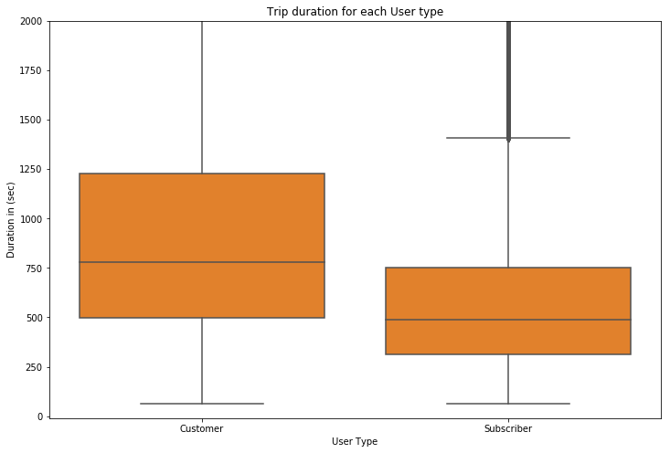

```python
plt.figure(figsize=(12,8))
base_color = sns.color_palette()[1]
plt.ylim([-10, 2000])
sns.boxplot(data=ford_bikes, x = 'user_type', y='duration_sec', color = base_color);
plt.xlabel('User Type')
plt.ylabel('Duration in (sec)')
plt.title("Trip duration for each User type");
```

## Daily trip durations and how they vary across gender

> On a daily basis, the "Other" gender takes the longest times on their trips with Male members taking the least time across all days.

> The periods with the highest trip durations are on weekends(Saturdays & Sundays) across all genders.

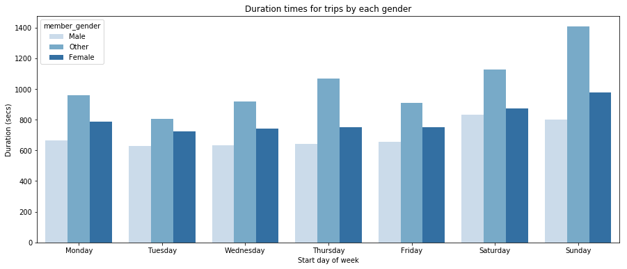

```python
plt.figure(figsize=(15,6))
sns.barplot(data=ford_bikes, y = 'duration_sec', x='start_day', hue = 'member_gender', ci=None, palette = 'Blues');
plt.title('Duration times for trips by each gender');
plt.ylabel('Duration (secs)')
plt.xlabel('Start day of week');
```

## Daily trip durations and how they vary across User types

> The Customer user type has the highest trip durations relative to Subscriber User types The Customer members travel longer during weekends while the trend is relatively flat for subscriber type.

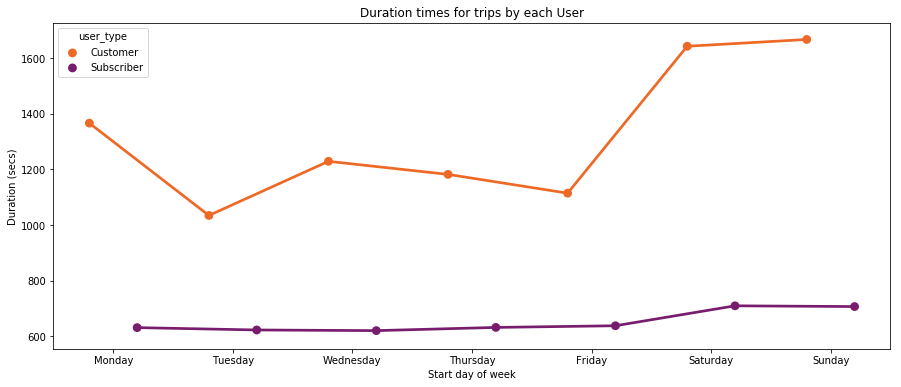

```python
plt.figure(figsize=(15,6))
sns.pointplot(data=ford_bikes, y = 'duration_sec', x='start_day', hue = 'user_type',
            dodge = 0.4, ci=None, palette = 'inferno_r');
plt.title('Duration times for trips by each User');
plt.ylabel('Duration (secs)')
plt.xlabel('Start day of week');
```